# iter-binomial-laplace

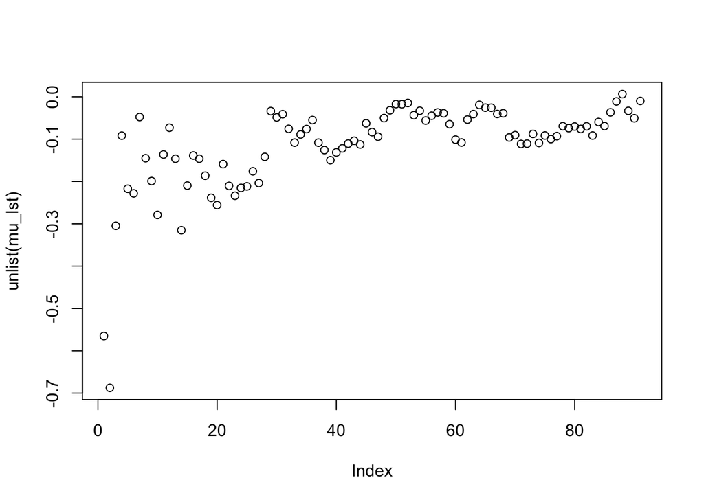

```r
plot(unlist(mu_lst))
```

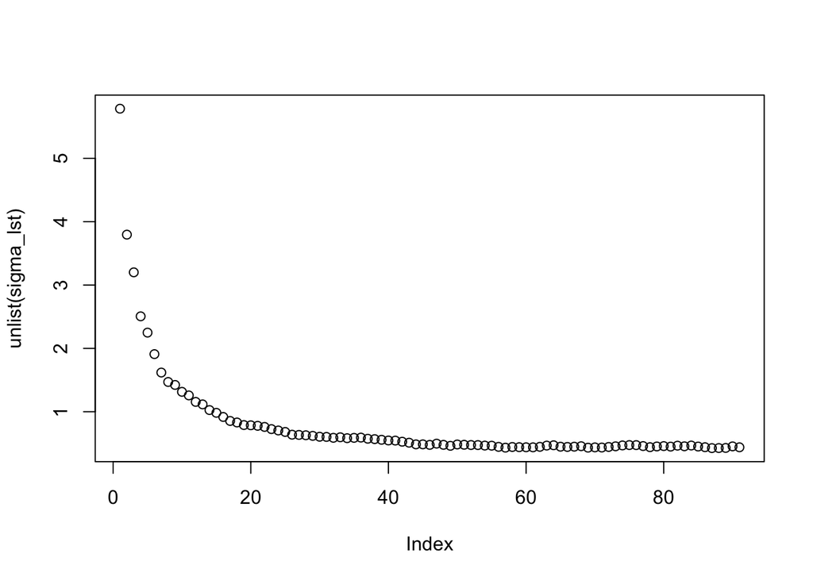

```r
plot(unlist(sigma_lst))
```

The second experiment with different prior, $N(1, 1^2)$ which is unsymmetrical unlike $N(0, 10^2)$, also converge to the same distribution. A likeable explanation is the recurrence of parameter values within well-calibrated region as opposed to that are not. For instance, if $logit(p)$ starts from 0.9, is likely to form a non-normal posterior whose mode is more likely to move away from 0.9. On the other hand, parameter values near .5 forms a symmetric and stable posterior which in most cases has its mode near .5.

# Experiment 2.

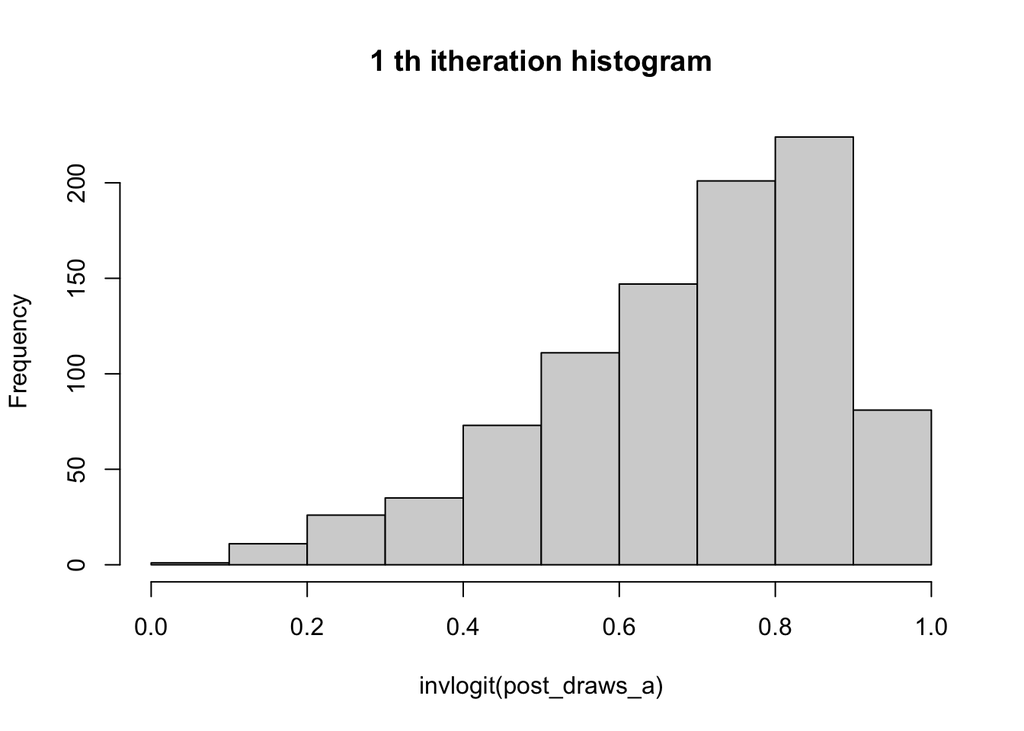

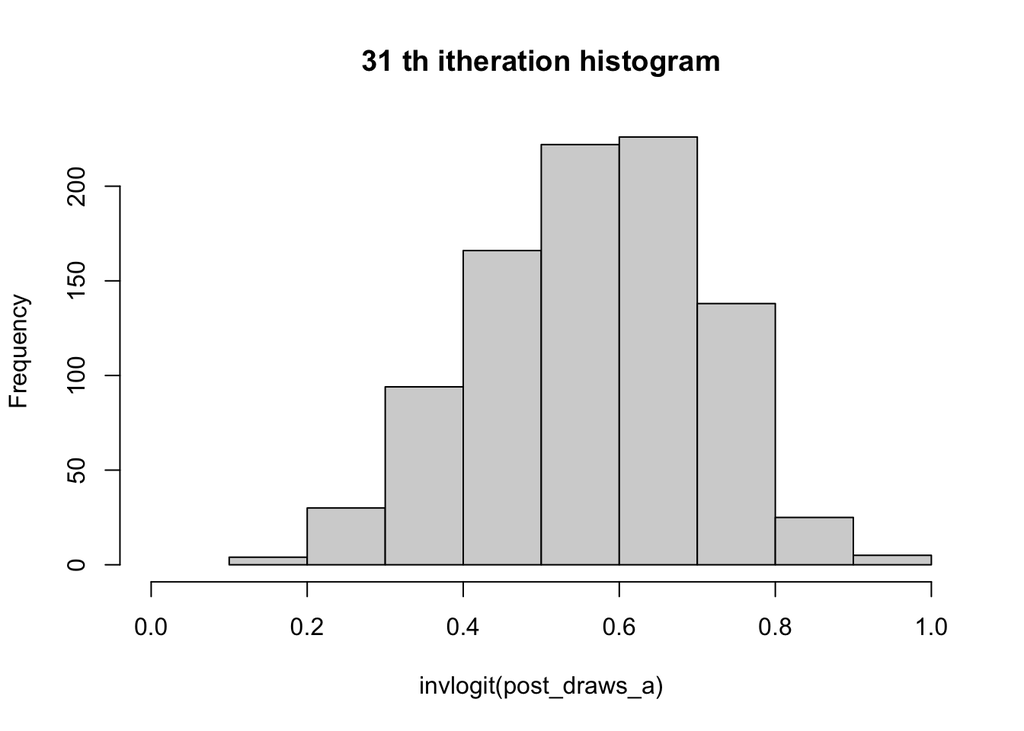

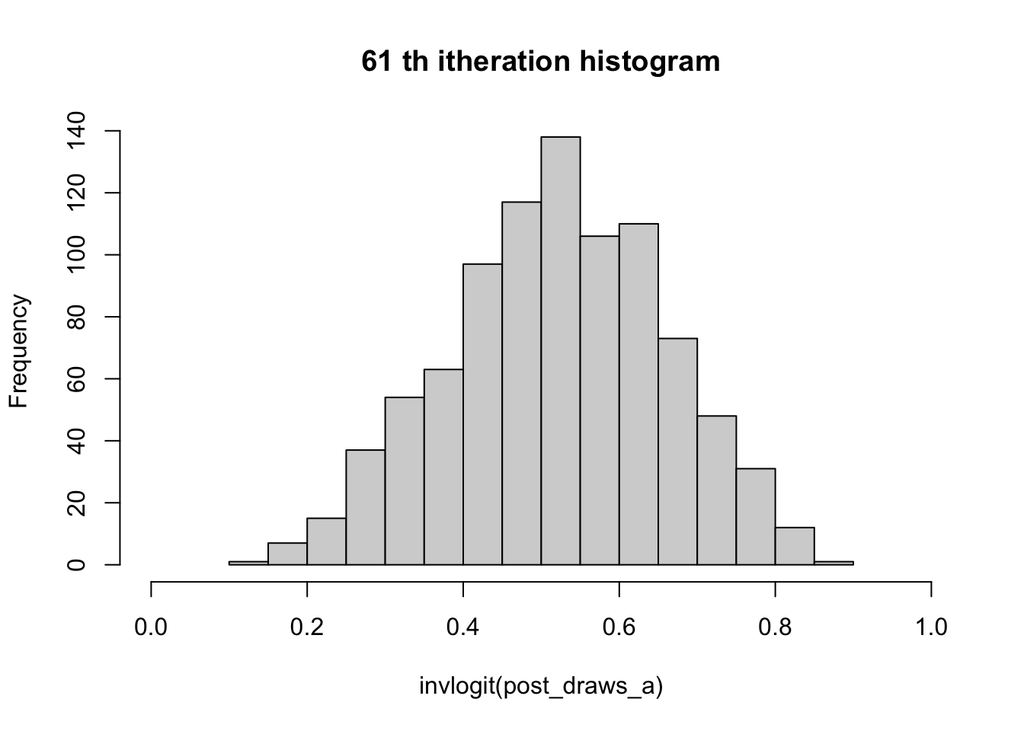

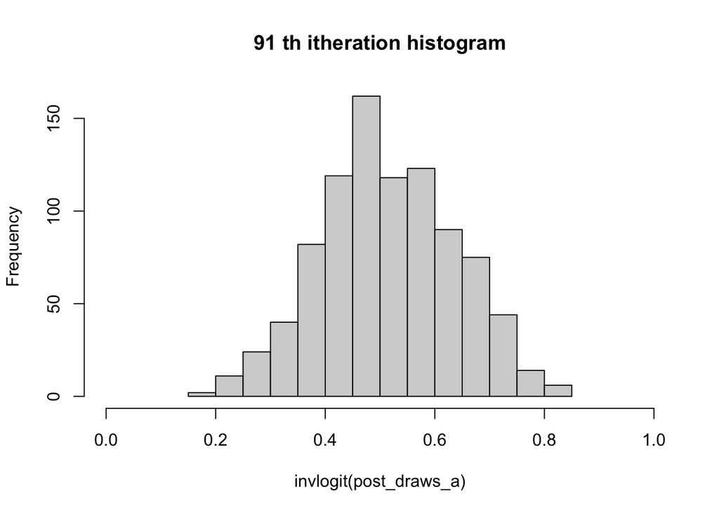

```r
# change prior hyperparameters
mu <- 1
sigma <- 1
SBC_iter <- 91
mu_lst <- list()
sigma_lst <- list()
for (j in 1:SBC_iter){
  post_draws_a <- c()
  a <- rnorm(nsims, mu, sigma)
  for (i in 1:nsims) {
    p <- invlogit(a[i])
    y <- rbinom(nobs, nsize, p)
    dat <- list(Y=as.array(y), nsize=nsize, nobs=nobs, mu = mu, sigma = sigma)
    fit <- optimizing(model, data = dat, hessian = TRUE)

    # approximate posterior mean via posterior mode
    post_mean_a <- fit$par["a"]

    # approximate posterior sd via (sqrt) of the inverse negative Hessian
    post_sd_a <- sqrt(solve(-fit$hessian))
    post_draws_a <- c(post_draws_a, rnorm(ndraws, post_mean_a, post_sd_a))
  }
  if ((j-1) %% 30 == 0){
    hist(invlogit(post_draws_a), xlim = range(0,1), main = paste(j, "th itheration histogram"))
  }

  # update hyperparameters depending on inference algorithm
  mu_est <- mean(post_draws_a)
  mu <- mu_est
  sigma_est <- sd(post_draws_a)
  sigma <- sigma_est
  # compare with previous hyperparameters

  mu_lst <- c(mu_lst, mu)
  sigma_lst <- c(sigma_lst, sigma)
}
```

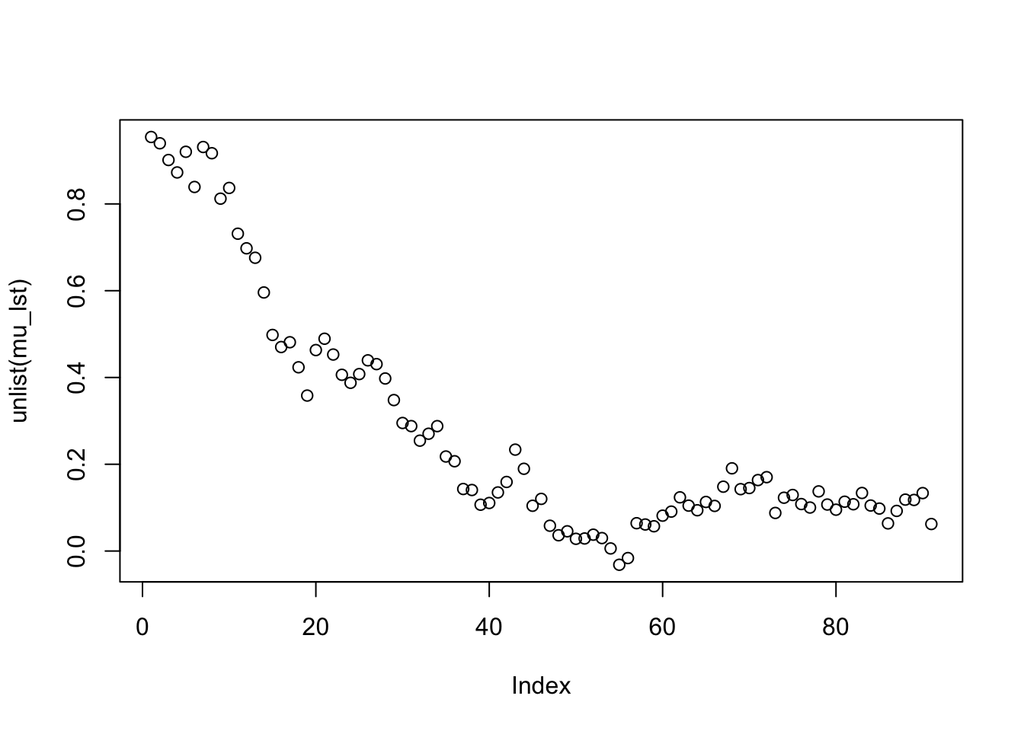

```r
plot(unlist(mu_lst))
```

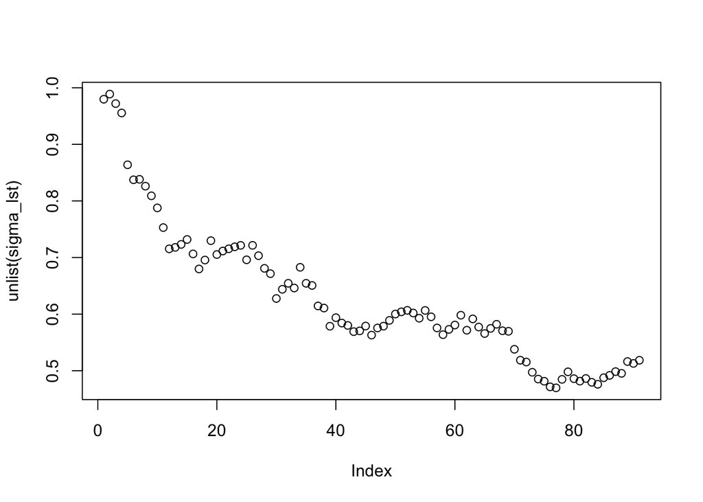

```r
plot(unlist(sigma_lst))
```